# Immunephenotypes of SARS-CoV-2-specific T cells

11 May 2021

## Introduction

- The COVID-19 pandemic is caused by the highly infectious virus; SARS-CoV-2.
- CD8+ T cells perform essential functions in the control and elimination of viral infections
- Here, we analyze the immunophenotypes of CD8 T cells that can recognize peptides from the SARS-CoV-2 genome
- We compare COVID-19 patients with healthy donors (HD) never exposed to the virus.
- Furthermore, we compare the phenotypes to the severity of the disease.
- We also compare the phenotype of the SARS-CoV-2 specific CD8 T cells with T cells that recognize common viruses.

## Materials and methods

### Phenotype data

- Phenotyping of immune cells provides imformation abouts the activation status of the cells
- This is obtained through antibody staining and flow cytometry, which transforms a fluorescent signal into a voltage.
- Cell populations of specific phenotype is gated in FlowJo software, and frequencies of positive cells can afterwards exported as an .xlsx file

## Raw data

- The dataset is obtained from S. K. Saini *et al., Sci. Immunol.* (2021)

```
## # A tibble: 82 x 25
##    SampleID  Hospital_status `lymphocytes/sin… `lymphocytes/si… `lymphocytes/si…
##    <chr>     <chr>           <chr>             <chr>            <chr>
##  1 Patient_1 Hospitalized    28.7              20.399999999999… 1.66
##  2 Patient_2 Hospitalized    12.5              84.1             44.9
##  3 Patient_3 Hospitalized    27.3              91.2             16.7
##  4 Patient_4 Hospitalized    5.9               23.3             8.4600000000000…
##  5 Patient_5 Hospitalized    16.8              40               11.2
##  6 Patient_6 Hospitalized    4.83              49.2             25.9
##  7 Patient_7 NA              NA                76.7             32.1
##  8 Patient_8 Hospitalized    1.94              45.6             5.41
##  9 Patient_9 Hospitalized    3.76              34.1             6.15
## 10 Patient_… Hospitalized    1.69              31.5             12
## # … with 72 more rows, and 20 more variables:
## #   lymphocytes/singlet/live_cells/CD3+/CD8+/SARS_multimer+/CD69 <chr>,
## #   lymphocytes/singlet/live_cells/CD3+/CD8+/SARS_multimer+/PD-1 <chr>,
## #   lymphocytes/singlet/live_cells/CD3+/CD8+/SARS_multimer+/HLA-DR <chr>,
## #   lymphocytes/singlet/live_cells/CD3+/CD8+/SARS_multimer+/CD27 <chr>,
## #   lymphocytes/singlet/live_cells/CD3+/CD8+/SARS_multimer+/CD57 <chr>,
## #   lymphocytes/singlet/live_cells/CD3+/CD8+/SARS_multimer+/CD45RA-_CCR7+ <chr>,
## #   lymphocytes/singlet/live_cells/CD3+/CD8+/SARS_multimer+/CD45RA-_CCR7- <chr>,
## #   lymphocytes/singlet/live_cells/CD3+/CD8+/SARS_multimer+/CD45RA+_CCR7- <chr>,
## #   lymphocytes/singlet/live_cells/CD3+/CD8+/SARS_multimer+/CD45RA+_CCR7+ <chr>,
## #   lymphocytes/singlet/live_cells/CD3+/CD8+/SARS_multimer+/CD38+_CD39+ <chr>,
## #   lymphocytes/singlet/live_cells/CD3+/CD8+/SARS_multimer+/CD38+_CD69+ <chr>,
## #   lymphocytes/singlet/live_cells/CD3+/CD8+/SARS_multimer+/CD38+_HLA-DR+ <chr>,
## #   lymphocytes/singlet/live_cells/CD3+/CD8+/SARS_multimer+/CD38+_PD-1+ <chr>,
## #   lymphocytes/singlet/live_cells/CD3+/CD8+/CEF_multimer+/CD38 <chr>,
## #   lymphocytes/singlet/live_cells/CD3+/CD8+/CEF_multimer+/CD39 <chr>,
## #   lymphocytes/singlet/live_cells/CD3+/CD8+/CEF_multimer+/CD69 <chr>,
## #   lymphocytes/singlet/live_cells/CD3+/CD8+/CEF_multimer+/PD-1 <chr>,
## #   lymphocytes/singlet/live_cells/CD3+/CD8+/CEF_multimer+/HLA-DR <chr>,
## #   lymphocytes/singlet/live_cells/CD3+/CD8+/CEF_multimer+/CD27 <chr>,
## #   lymphocytes/singlet/live_cells/CD3+/CD8+/CEF_multimer+/CD57 <chr>
```

## Data wrangling

### Tidying the data set

- Change NA values
- Add cohort group as a new variable
- Collapse multiple columns into two columns: Gating and Fraction
- Splitting the gating path into two new columns: Last and parent population

```
## # A tibble: 1,886 x 8
##    SampleID  cohort_type Hospital_status Gating          T_cell Parent_populati…
##    <chr>     <chr>       <chr>           <chr>           <chr>  <chr>
##  1 Patient_1 Patient     Hospitalized    lymphocytes/si… CD8    CD8+
##  2 Patient_1 Patient     Hospitalized    lymphocytes/si… CD8    SARS_multimer+
##  3 Patient_1 Patient     Hospitalized    lymphocytes/si… CD8    SARS_multimer+
##  4 Patient_1 Patient     Hospitalized    lymphocytes/si… CD8    SARS_multimer+
##  5 Patient_1 Patient     Hospitalized    lymphocytes/si… CD8    SARS_multimer+
##  6 Patient_1 Patient     Hospitalized    lymphocytes/si… CD8    SARS_multimer+
##  7 Patient_1 Patient     Hospitalized    lymphocytes/si… CD8    SARS_multimer+
##  8 Patient_1 Patient     Hospitalized    lymphocytes/si… CD8    SARS_multimer+
##  9 Patient_1 Patient     Hospitalized    lymphocytes/si… CD8    SARS_multimer+
## 10 Patient_1 Patient     Hospitalized    lymphocytes/si… CD8    SARS_multimer+
## # … with 1,876 more rows, and 2 more variables: Last_population <chr>,
## #   Fraction <dbl>
```

## Creating plots

- Reading covid_data_augment
- Filter on Parent and Last population
- Generate plot using ggplot - Boxplot and dotplot
- Multiple plots viewed as facetwrap
- Used geomsigif with Kruskal test

## Results

## Figure A

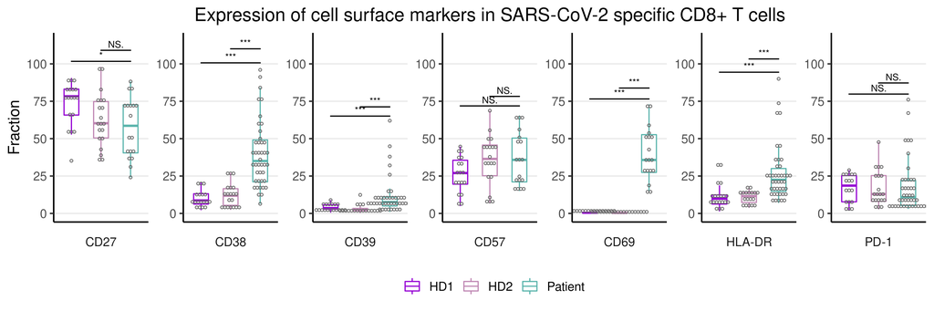

[figure not shown]

## Figure B

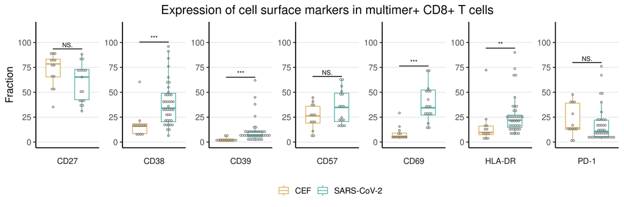

## Figure C

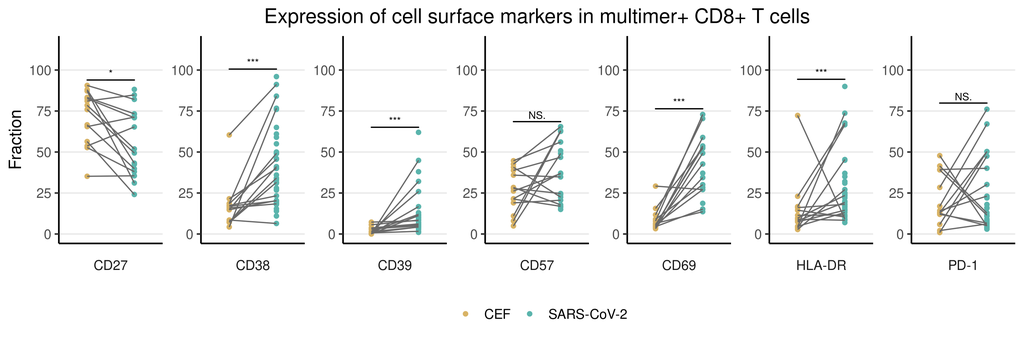